# Week 5 Notes and Work

Arin Vansomphone

2022-07-21

# Epidemiology Book Questions

1. The major purpose of random assignment in a clinical trial is to facilitate the measurement of outcome variables.
2. An advertisement… Based on the evidence given above, the claim may be incorrect because no control or comparison group was involved.
3. The purpose of a double blind or double masked study is to avoid observer and subject bias.
4. In many studies… The underlying assumption justifying a one-sided rather than a two-sided test is the expectation before doing the study was that estrogens cause endometrial cancer of the uterus.
5. In a randomized trial, a planned crossover design must take into account the problem of possible residual effects of the first therapy.
6. A randomized trial… This is therefore an example of a type 1 error.
7. All of the following are potential benefits of a randomized clinical trial, except the external validity of the study is increased.
8. The number of patients needed in each therapy group is 57.

# Reproducing the Figure

```r
# loading the packages
library(tidyverse)

# importing the datasets
demoinfo <- read_csv("accord_key.csv")
bloodpress <- read_csv("bloodpressure.csv")
bloodsugar <- read_csv("hba1c.csv")
```

Next I joined the `bloodsugar` database with the `demoinfo` database to allow us to sort the observations by arm:

```r
bigdataset <- demoinfo %>%
  inner_join(bloodsugar, by = "MaskID")
```

Creating the `glycemic_arm` variable in our `bigdataset`:

```r
# converting arm to character type and creating values for 0
bigdataset$arm <- as.character(bigdataset$arm)
glycemicarm_standard = c("1", "2", "5", "6")

# creating the new variable and assigning values
bigdataset$glycemic_arm = "Intensive therapy"
bigdataset$glycemic_arm[bigdataset$arm %in% glycemicarm_standard] = "Standard therapy"
```

The next thing to fix is the unit of time. From the information in the label dictionary, the number after F in each visit pertains to the months after the trial started. The numbers go in multiples of 4, so therefore every 3 visits equals 1 year. I used the same structure of code from creating the `glycemic_arm` variable to create the `years` variable:

```r
# creating values to correspond each visit to a year
year0 = "BLR" # baseline is year 0 because it is the starting point
year1 = c("F04", "F08", "F12")
year2 = c("F16", "F20", "F24")
year3 = c("F28", "F32", "F36")
year4 = c("F40", "F44", "F48")
year5 = c("F52", "F56", "F60")
year6 = c("F64", "F68", "F72")
year7 = c("F76", "F80", "F84")

# creating the year variable and assigning values
bigdataset$year = 0
bigdataset$year[bigdataset$Visit %in% year1] = 1
bigdataset$year[bigdataset$Visit %in% year2] = 2
bigdataset$year[bigdataset$Visit %in% year3] = 3
bigdataset$year[bigdataset$Visit %in% year4] = 4
bigdataset$year[bigdataset$Visit %in% year5] = 5
bigdataset$year[bigdataset$Visit %in% year6] = 6
bigdataset$year[bigdataset$Visit %in% year7] = 7
```

Now we can reproduce the figure from the information in our `bigdataset`. I’ve removed the EXIT values from the graph because they do not produce a good progression:

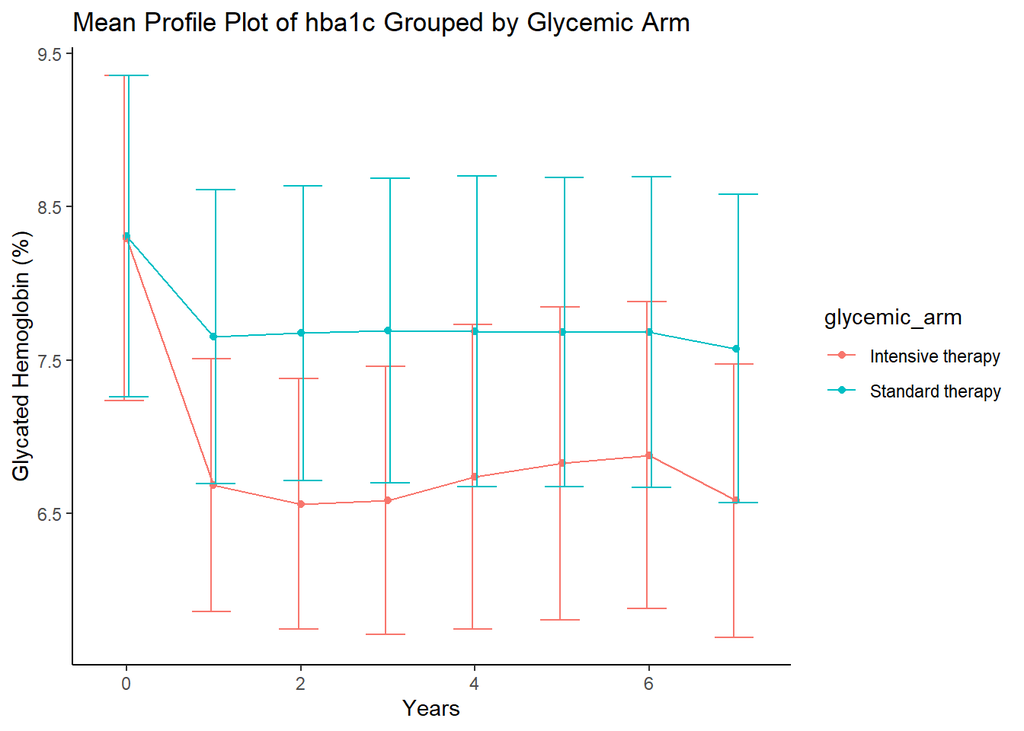

```r
bigdataset %>%
  filter(Visit != "EXIT") %>% #removing the exit values
  group_by(year, glycemic_arm) %>%
  summarize(mean = mean(hba1c),
            sd = sd(hba1c)) %>%
  ggplot(aes(x = year, y = mean, color = glycemic_arm)) +
  geom_point() +
  geom_line(aes(group = glycemic_arm)) +
  geom_errorbar(aes(ymin = mean - sd, ymax = mean + sd), #The error bars
                position = position_dodge(0.1)) +
  theme_classic() +
  labs(title = "Mean Profile Plot of hba1c Grouped by Glycemic Arm",
       x= "Years",
       y = "Glycated Hemoglobin (%)")
```

I believe that there is a rebound in the intensive therapy hemoglobin levels due to the halt of the trial. According to the 2008 paper, the intensive therapy studies were halted after it was linked to higher mortality rates. Thus, the group must have had their treatment lessened, which lead to a rebound in the hemoglobin levels.

# R for Data Science Chapters 22-25

### Chapter 22: Introduction

- Recommended way to split your data:
  - 60% of your data goes into a training (or exploration) set
  - 20% goes into a query set (compare models or visualization)
  - 20% is saved for a test set (you can only use the data ONCE)

### Chapter 23: Model basics

- The goal of a model is to provide a simple low-dimensional summary of a dataset, capture true signals and ignore noise
- Two parts to a model:
  1. Define a family of models: linear, quadratic, etc.
  2. Generate a fitted model by finding the model from the family that is closest
- When you want to find the line of best fit, use `geom_abline()` and `optim()` to do so (documentation in the book)
- Linear models can be solved with `lm()`
- Residuals: the distances between the observed and predicted values
- `model_matrix()` function takes a data frame and a formula and returns the tibble that defines the model equation
- Models with categorical `x`s will predict the mean value for each category
- For two continuous variables, you need to consider both values of `x1` and `x2` simultaneously
- Use `poly` if you want a smooth curve from polynomials

### Chapter 24: Model building

- Taking the log of data allows you to see a linear relationship
- Models can add more than one predictor
- Calculating residues to eliminate effects
- `MASS::rlm()` removes the effect of outliers on your model
- Create a large toolbox for yourself!

### Chapter 25: Many models

- List columns and implementing them into dataframes
- Modeling functions are stored in the `modelr` package
- To create a model with more than one case, use a nested data frame (`nest()`)
  - In a nested dataframe, each row is a group
- Unnest dataframes with `unnest()`
- The R^2 variable shows how well a dataset fits with a model. Usually anything below 0.25 is strange
- A list column is where each column entry is a list
- Simplifying list colymns:
  - If you want a single value, use `mutate()` with `map_lgl()`, `map_int()`, `map_dbl()` or `map_chr()` to create an atomic vector
  - If you want many values, use `unnest()` to convert back to regular columns
- You can only unnest multiple list-columns if they all have the same number of rows
- `broom::glance(model)` returns a row for each model. Each column gives a model summary
- `broom::tidy(model)` returns a row for each coefficient in the model

# Rstudio.cloud Primer

I did the functions primer:

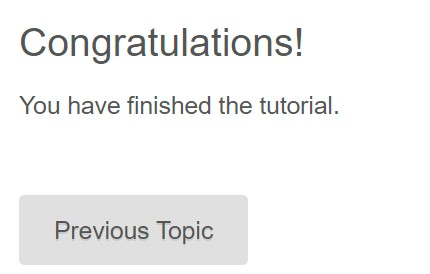

Function Basics:

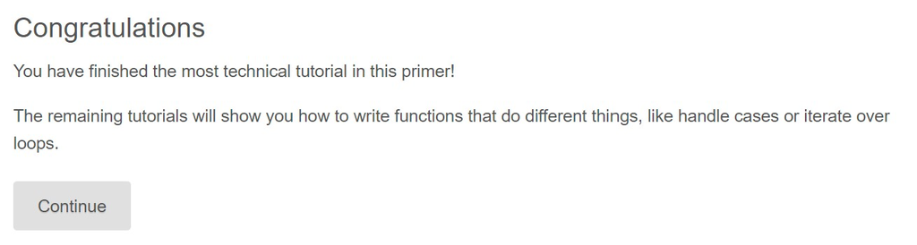

Environments and Scoping:

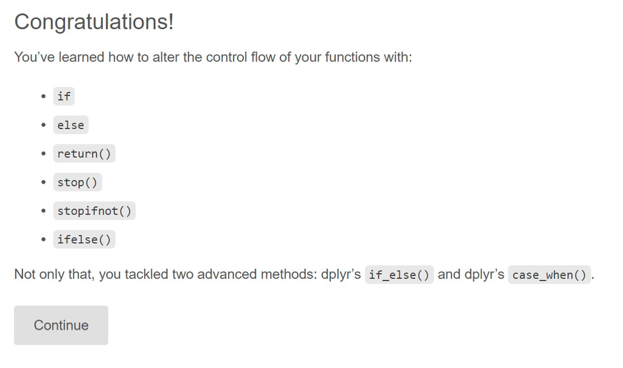

Advanced Control Flow:

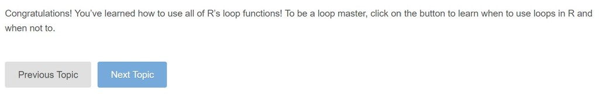

Loops:

Example: using `case_when` for vectorized arguments:

```r
clean <- function(x) {
  case_when(
  x == -99 ~ NA_real_,
  x == "." ~ NA_real_,
  x == "" ~ NA_real_,
  x == "NaN" ~ NA_real_,
  TRUE ~ x
  )
}
```